# Evidence & decision making

## Evidence based decision making

- Evidence-based decision making depends upon decision makers having access to, and understanding evidence
- Our goal is to ensure the results of our projects inform their decision making.
- Many projects do not engage the key decision makers
- Are surprised when no one pays any attention to their work
- Have no idea how decisions are made

## What we need to know:

- How are decisions made?
- Who are the key decision makers?
  - *These people may sit outside formal hierarchies*
- How can we engage them in this project?

[figure not shown]

## What is evidence?

- Evidence is an observation that is consistent with a certain idea being true.
- In science, this evidence needs to be observable, and reproducible.
- Therefore scientific concepts need to be backed up by reproducible observations
- The quality of the evidence matters more than the quantity of evidence
- Consider a bank robbery…

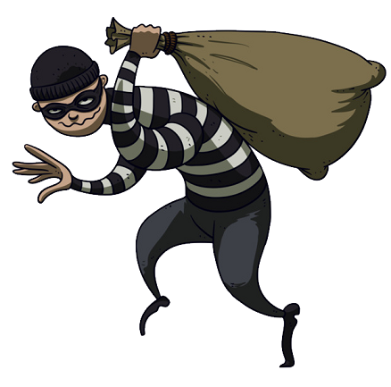

## Inference

- Inference = coming to a conclusion through a process of reasoning
- Inference also speaks about the quality of our evidence

## Reasoning

### Deduction

- Only birds have feathers. [Premise 1]
- A chicken has feathers. [Premise 2]
- Therefore a chicken is a bird. [Conclusion]

## Reasoning

### Induction

- All of the cows for sale I have ever seen have been brown. [Premise 1]
- My mother is going to buy a cow. [Premise 2]
- Therefore the new cow will probably be brown. [Conclusion]
- Induction allows us to make probable conclusions from samples.
- Statistics is the science of inductive reasoning.

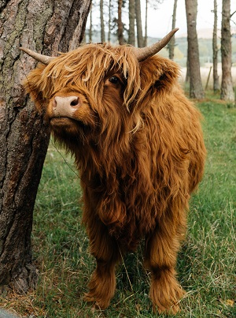

## Strength of inference

- Our ability to remove the possibility that the same outcome could be produced by a different explanation
- The more explanations you can successfully eliminate the stronger the inference

## Ancedotal evidence

- Aunt Elaine says that high rice bran feed is the best fish food.
- Its the opinion of Aunt Elaine.
- There is no measurement.
- The change could be explained many alternate pathways.

## Observational study

- Aunt Elaine’s fish production in her pond went from an 28.2 kg to 32.1 kg in the year when she changed from a low rice bran feed to a high rice bran feed
- Fish production changed between years in Aunt Elaine’s pond.
- We also know that this coincided with the change to a high rice bran fish feed.
- Results could be one-off (no replication), a result of local conditions or due to a difference unrelated to fish feed.

## Constrained study

- In a before-after study involving 12 farmers, each with one pond, on average fish production improved between years from an average of 27.4 kg to 34.2 kg when a change was made from a low rice bran feed to a high rice bran feed
- Fish production coincided with the change to a high rice bran fish feed
- Consistent across all ponds so not likely due to local pond conditions
- Could still be due to a difference between years unrelated to the type of fish feed

## Manipulated experiment

- In a before-after-control-impact study involving 12 farmers, each with one pond, in year 1 all fish ponds received a low rice bran feed, in year 2 a random selection of 6 fish ponds received a high rice bran feed while the other 6 received the low rice bran feed.
- In year 1 fish production averaged 27.4 kg, while in year 2 the ponds receiving the low rice bran feed averaged 35.4 kg, and the ponds receiving the high rice bran feed averaged 32.9 kg.
- Fish production increased in the second year.
- There was an inter-year increase unrelated to fish feed.
- There may or may not be an additional effect of fish feed (going in the direction opposite of that expected)

## Think about inference not numbers

- How can we prove that an intervention is working?
- and we wouldn’t get the same result without it?
- Sometimes referred to as “**Counterfactual approaches / thinking**”

## Single site: 1 measurement *(baseline only)*

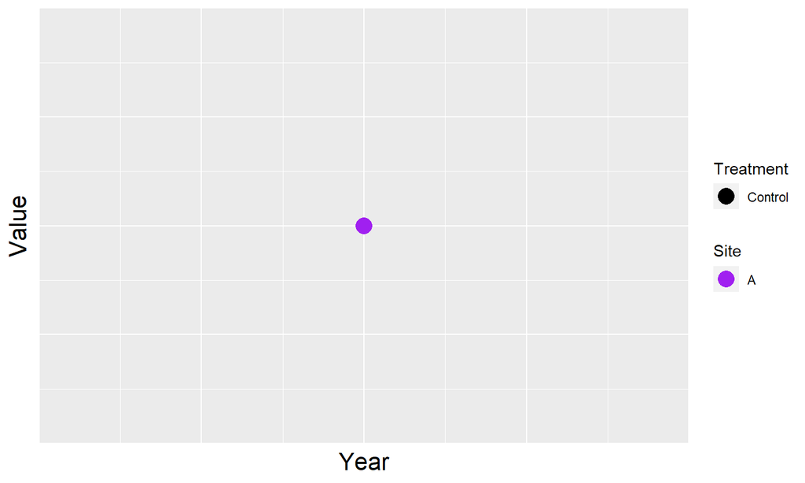

- **Advantage:** a starting point
- **Disadvantage:** just a lonely piece of information, no inference

## Single site: 2 measurements *(longitudinal study)*

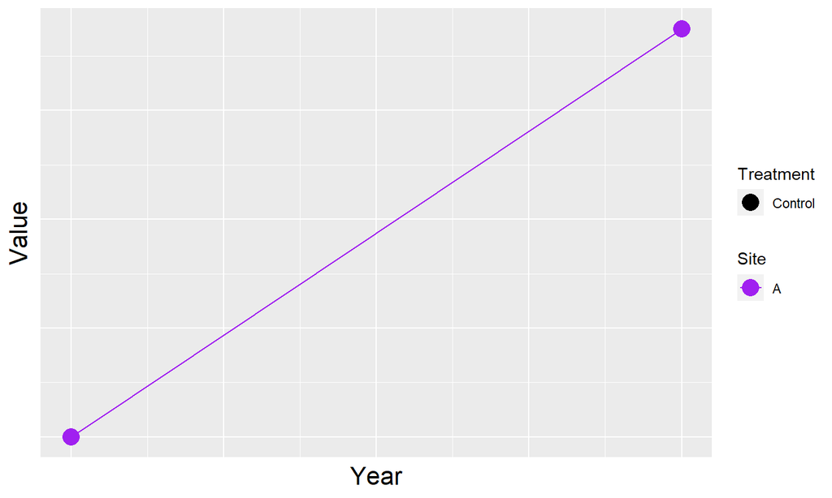

- **Advantage:** we start to see differences through time
- **Disadvantage:** low sample size - can’t distinguish between signal and noise

## Single site: 3 measurements

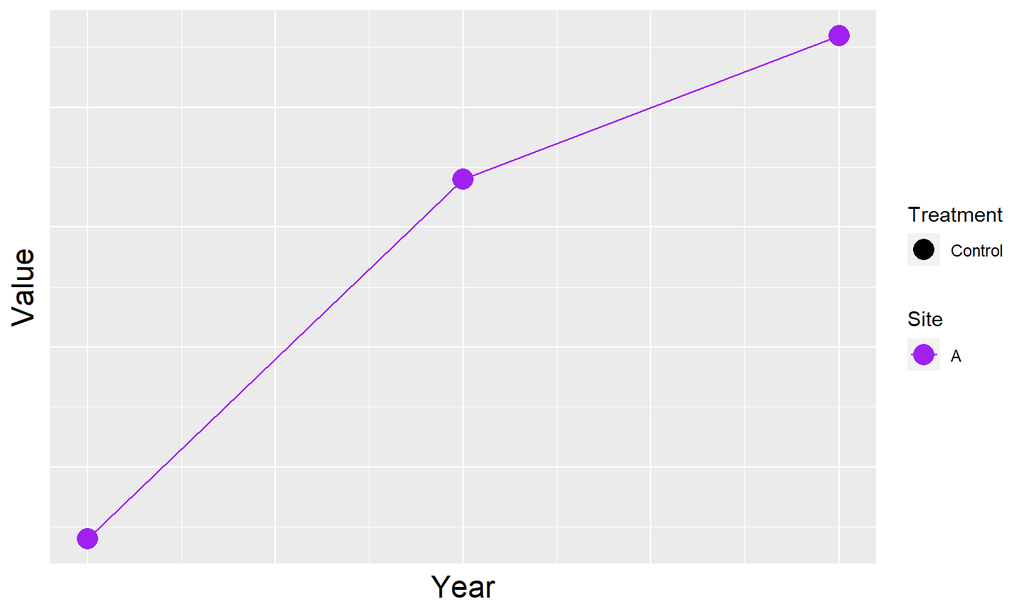

- **Advantage:** more measurements = more confidence it isn’t noise
- **Disadvantage:** more measurements = more work

## Two sites: 3 measurements

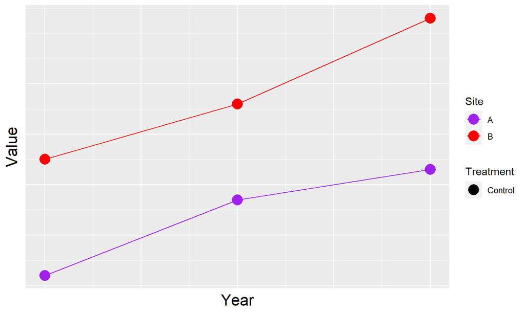

- **Advantage:** we can see inherent differences between sites
- **Disadvantage:** doubled the amount of monitoring

## Control-Impact: *measuring after intervention*

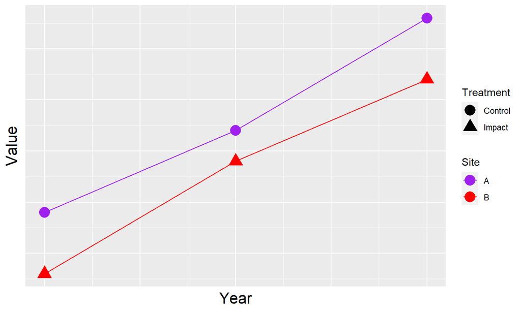

- **Advantage:** a counterfactual is measured
- **Disadvantage:** sites may not be replicates (A > B: incorrect), we don’t know the “before” state

## Before-After one site only

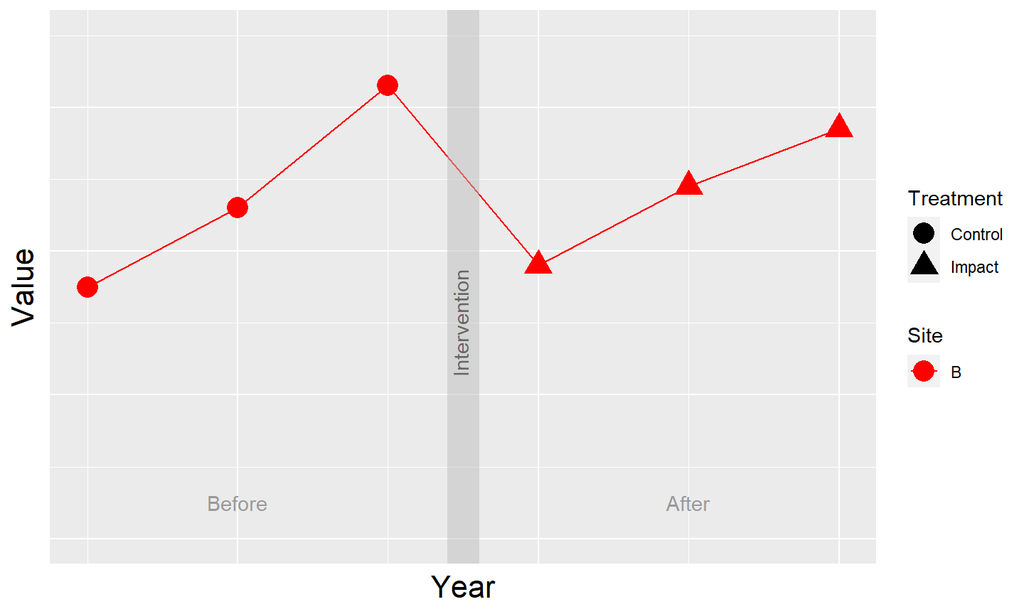

- **Advantage:** the site is its own “control”
- **Disadvantage:** could be just a temporal effect coinciding with the intervention, or just noise, absence of a temporal “control” impacts inference

## Before-After Control-Impact

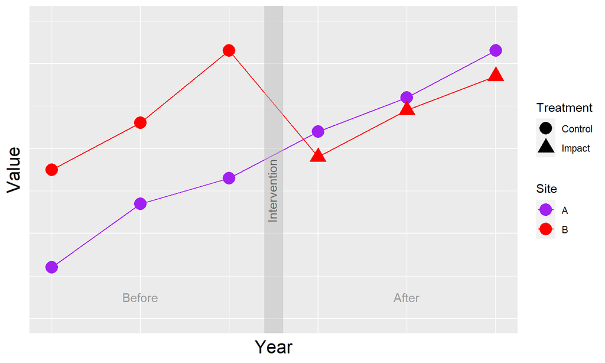

- **Advantage:** we know how sites inherently differ, there is a temporal control, strong inference.
- **Disadvantage:** we need to have the social license for non-intervention in the temporal control

## Better inference

### For experiments

- Use a control group (*easier said than done*)
- Avoid bias by random assignment to treatment (e.g intervention vs control)
- Include “before” monitoring to understand site based differences

## Better inference

- More sites give us confidence to apply our results more generally
- A greater sample size (number of observations) allows us to better separate signal from noise and ask more sophisticated questions
- Simulate your study design before hand to ensure sample size will be adequate
- **BE PRACTICAL: easier to simplify your question rather than increase sample size**

## No social license for “controls”

- Consider staggered entry (*controls are created through time lags*)
- Every community gets the exactly the same interventions but the timing of when they receive it differs

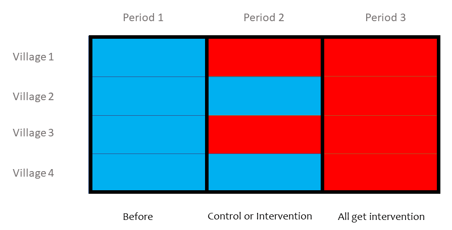

## Practical staggered entry

Staggered entry: consider deploying 2 mutually exclusive projects

- 1st year: baseline monitoring
- 2nd year: communities randomly receive project A or B
- 3rd year: communities receive the missing project
- Advantage: BACI inference
- Advantage: communities do not see themselves as penalised

## Inference in developing countries

### Organisational capacity is an issue

- **CBOs:** qualititative methods e.g. testimonials (narrative)
- **small NGOs:** before-after perception surveys (tables & excel graphs)
- **national NGOs/ government departments:** field monitoring: before-after, less often control-impact (basic statistical methods e.g. t-tests, chi-squared tests)
- **INGOs:** potential for some advanced statistical methods (e.g. linear mixed-effect models, use of remote sensing data)
- **international collaborations with researchers:** novel statistical methods and innovative project design

## Decision makers

- You now understand the effectiveness of your project or now know how to exploit a pattern in the data *e.g. new anti-malaria practice*
- How do you ensure the decision makers are aware of this information?
- How do you ensure the decision makers use this information in their decision making?
- *Ideally:*
  - you developed a plan early on
  - decision makers have been actively involved all along

## Summary

- Decision makers need to be involved early
- Focus monitoring on inference not numbers
- Aim for the best inference within budget constraints & organisational ability
- Be realistic
  - *If it will be a challenge for a CBO to collect and evaluate data, accept qualitative data such as testimonials*
  - A well financed, multi-year project run by a large INGO should be held to a much higher level of inference

## Next up …

*Strategy & data integration*

- Most organisations don’t understand how data and strategy fit together.
- Data is not just for experiments…